# Risk Factor Analysis

## Outcome Variable

**Outcome Variable:** ever_wasted

## Predictor Variables

**Intervention Variable:** nrooms

**Adjustment Set:**

- arm
- sex
- W_mage
- meducyrs
- feducyrs
- hhwealth_quart
- hfoodsec
- W_mhtcm
- W_mwtkg
- W_mbmi
- W_nchldlt5
- W_parity
- impfloor
- impsan
- safeh20
- delta_W_mage
- delta_meducyrs
- delta_feducyrs
- delta_hhwealth_quart
- delta_hfoodsec
- delta_W_mhtcm
- delta_W_mwtkg
- delta_W_mbmi
- delta_W_nchldlt5
- delta_W_parity
- delta_impfloor
- delta_impsan
- delta_safeh20

## Stratifying Variables

The analysis was stratified on these variable(s):

- agecat
- studyid
- country

## Data Summary

| agecat | studyid | country | nrooms | ever_wasted | n_cell | n |
| --- | --- | --- | --- | --- | --- | --- |
| 0-24 months | ki0047075b-MAL-ED | BANGLADESH | 4+ | 0 | 9 | 242 |
| 0-24 months | ki0047075b-MAL-ED | BANGLADESH | 4+ | 1 | 3 | 242 |
| 0-24 months | ki0047075b-MAL-ED | BANGLADESH | 1 | 0 | 92 | 242 |
| 0-24 months | ki0047075b-MAL-ED | BANGLADESH | 1 | 1 | 60 | 242 |
| 0-24 months | ki0047075b-MAL-ED | BANGLADESH | 2 | 0 | 37 | 242 |
| 0-24 months | ki0047075b-MAL-ED | BANGLADESH | 2 | 1 | 13 | 242 |
| 0-24 months | ki0047075b-MAL-ED | BANGLADESH | 3 | 0 | 20 | 242 |
| 0-24 months | ki0047075b-MAL-ED | BANGLADESH | 3 | 1 | 8 | 242 |
| 0-24 months | ki0047075b-MAL-ED | BRAZIL | 4+ | 0 | 113 | 210 |
| 0-24 months | ki0047075b-MAL-ED | BRAZIL | 4+ | 1 | 14 | 210 |
| 0-24 months | ki0047075b-MAL-ED | BRAZIL | 1 | 0 | 4 | 210 |
| 0-24 months | ki0047075b-MAL-ED | BRAZIL | 1 | 1 | 0 | 210 |
| 0-24 months | ki0047075b-MAL-ED | BRAZIL | 2 | 0 | 18 | 210 |
| 0-24 months | ki0047075b-MAL-ED | BRAZIL | 2 | 1 | 2 | 210 |
| 0-24 months | ki0047075b-MAL-ED | BRAZIL | 3 | 0 | 55 | 210 |
| 0-24 months | ki0047075b-MAL-ED | BRAZIL | 3 | 1 | 4 | 210 |
| 0-24 months | ki0047075b-MAL-ED | INDIA | 4+ | 0 | 16 | 235 |
| 0-24 months | ki0047075b-MAL-ED | INDIA | 4+ | 1 | 9 | 235 |
| 0-24 months | ki0047075b-MAL-ED | INDIA | 1 | 0 | 44 | 235 |
| 0-24 months | ki0047075b-MAL-ED | INDIA | 1 | 1 | 40 | 235 |
| 0-24 months | ki0047075b-MAL-ED | INDIA | 2 | 0 | 37 | 235 |
| 0-24 months | ki0047075b-MAL-ED | INDIA | 2 | 1 | 41 | 235 |
| 0-24 months | ki0047075b-MAL-ED | INDIA | 3 | 0 | 24 | 235 |
| 0-24 months | ki0047075b-MAL-ED | INDIA | 3 | 1 | 24 | 235 |
| 0-24 months | ki0047075b-MAL-ED | NEPAL | 4+ | 0 | 93 | 236 |
| 0-24 months | ki0047075b-MAL-ED | NEPAL | 4+ | 1 | 38 | 236 |
| 0-24 months | ki0047075b-MAL-ED | NEPAL | 1 | 0 | 30 | 236 |
| 0-24 months | ki0047075b-MAL-ED | NEPAL | 1 | 1 | 22 | 236 |
| 0-24 months | ki0047075b-MAL-ED | NEPAL | 2 | 0 | 24 | 236 |
| 0-24 months | ki0047075b-MAL-ED | NEPAL | 2 | 1 | 7 | 236 |

[output cut: 354 more lines]

The following strata were considered:

- agecat: 0-24 months, studyid: ki0047075b-MAL-ED, country: BANGLADESH
- agecat: 0-24 months, studyid: ki0047075b-MAL-ED, country: BRAZIL
- agecat: 0-24 months, studyid: ki0047075b-MAL-ED, country: INDIA
- agecat: 0-24 months, studyid: ki0047075b-MAL-ED, country: NEPAL
- agecat: 0-24 months, studyid: ki0047075b-MAL-ED, country: PERU
- agecat: 0-24 months, studyid: ki0047075b-MAL-ED, country: SOUTH AFRICA
- agecat: 0-24 months, studyid: ki0047075b-MAL-ED, country: TANZANIA, UNITED REPUBLIC OF
- agecat: 0-24 months, studyid: ki1000108-CMC-V-BCS-2002, country: INDIA
- agecat: 0-24 months, studyid: ki1000108-IRC, country: INDIA
- agecat: 0-24 months, studyid: ki1017093b-PROVIDE, country: BANGLADESH
- agecat: 0-24 months, studyid: ki1017093c-NIH-Crypto, country: BANGLADESH
- agecat: 0-24 months, studyid: ki1113344-GMS-Nepal, country: NEPAL
- agecat: 0-24 months, studyid: ki1114097-CONTENT, country: PERU
- agecat: 0-24 months, studyid: ki1135781-COHORTS, country: INDIA
- agecat: 0-24 months, studyid: kiGH5241-JiVitA-3, country: BANGLADESH
- agecat: 0-24 months, studyid: kiGH5241-JiVitA-4, country: BANGLADESH
- agecat: 0-6 months, studyid: ki0047075b-MAL-ED, country: BANGLADESH
- agecat: 0-6 months, studyid: ki0047075b-MAL-ED, country: BRAZIL
- agecat: 0-6 months, studyid: ki0047075b-MAL-ED, country: INDIA
- agecat: 0-6 months, studyid: ki0047075b-MAL-ED, country: NEPAL
- agecat: 0-6 months, studyid: ki0047075b-MAL-ED, country: PERU
- agecat: 0-6 months, studyid: ki0047075b-MAL-ED, country: SOUTH AFRICA
- agecat: 0-6 months, studyid: ki0047075b-MAL-ED, country: TANZANIA, UNITED REPUBLIC OF
- agecat: 0-6 months, studyid: ki1000108-CMC-V-BCS-2002, country: INDIA
- agecat: 0-6 months, studyid: ki1000108-IRC, country: INDIA
- agecat: 0-6 months, studyid: ki1017093b-PROVIDE, country: BANGLADESH
- agecat: 0-6 months, studyid: ki1017093c-NIH-Crypto, country: BANGLADESH
- agecat: 0-6 months, studyid: ki1113344-GMS-Nepal, country: NEPAL
- agecat: 0-6 months, studyid: ki1114097-CONTENT, country: PERU
- agecat: 0-6 months, studyid: ki1135781-COHORTS, country: INDIA
- agecat: 0-6 months, studyid: kiGH5241-JiVitA-3, country: BANGLADESH
- agecat: 0-6 months, studyid: kiGH5241-JiVitA-4, country: BANGLADESH
- agecat: 6-24 months, studyid: ki0047075b-MAL-ED, country: BANGLADESH
- agecat: 6-24 months, studyid: ki0047075b-MAL-ED, country: BRAZIL
- agecat: 6-24 months, studyid: ki0047075b-MAL-ED, country: INDIA
- agecat: 6-24 months, studyid: ki0047075b-MAL-ED, country: NEPAL
- agecat: 6-24 months, studyid: ki0047075b-MAL-ED, country: PERU
- agecat: 6-24 months, studyid: ki0047075b-MAL-ED, country: SOUTH AFRICA
- agecat: 6-24 months, studyid: ki0047075b-MAL-ED, country: TANZANIA, UNITED REPUBLIC OF
- agecat: 6-24 months, studyid: ki1000108-CMC-V-BCS-2002, country: INDIA
- agecat: 6-24 months, studyid: ki1000108-IRC, country: INDIA
- agecat: 6-24 months, studyid: ki1017093b-PROVIDE, country: BANGLADESH
- agecat: 6-24 months, studyid: ki1017093c-NIH-Crypto, country: BANGLADESH
- agecat: 6-24 months, studyid: ki1113344-GMS-Nepal, country: NEPAL
- agecat: 6-24 months, studyid: ki1114097-CONTENT, country: PERU
- agecat: 6-24 months, studyid: ki1135781-COHORTS, country: INDIA
- agecat: 6-24 months, studyid: kiGH5241-JiVitA-3, country: BANGLADESH
- agecat: 6-24 months, studyid: kiGH5241-JiVitA-4, country: BANGLADESH

### Dropped Strata

Some strata were dropped due to rare outcomes:

- agecat: 0-24 months, studyid: ki0047075b-MAL-ED, country: BANGLADESH
- agecat: 0-24 months, studyid: ki0047075b-MAL-ED, country: BRAZIL
- agecat: 0-24 months, studyid: ki0047075b-MAL-ED, country: PERU
- agecat: 0-24 months, studyid: ki0047075b-MAL-ED, country: SOUTH AFRICA
- agecat: 0-24 months, studyid: ki0047075b-MAL-ED, country: TANZANIA, UNITED REPUBLIC OF
- agecat: 0-24 months, studyid: ki1114097-CONTENT, country: PERU
- agecat: 0-6 months, studyid: ki0047075b-MAL-ED, country: BANGLADESH
- agecat: 0-6 months, studyid: ki0047075b-MAL-ED, country: BRAZIL
- agecat: 0-6 months, studyid: ki0047075b-MAL-ED, country: NEPAL
- agecat: 0-6 months, studyid: ki0047075b-MAL-ED, country: PERU
- agecat: 0-6 months, studyid: ki0047075b-MAL-ED, country: SOUTH AFRICA
- agecat: 0-6 months, studyid: ki0047075b-MAL-ED, country: TANZANIA, UNITED REPUBLIC OF
- agecat: 0-6 months, studyid: ki1000108-CMC-V-BCS-2002, country: INDIA
- agecat: 0-6 months, studyid: ki1114097-CONTENT, country: PERU
- agecat: 6-24 months, studyid: ki0047075b-MAL-ED, country: BANGLADESH
- agecat: 6-24 months, studyid: ki0047075b-MAL-ED, country: BRAZIL
- agecat: 6-24 months, studyid: ki0047075b-MAL-ED, country: INDIA
- agecat: 6-24 months, studyid: ki0047075b-MAL-ED, country: NEPAL
- agecat: 6-24 months, studyid: ki0047075b-MAL-ED, country: PERU
- agecat: 6-24 months, studyid: ki0047075b-MAL-ED, country: SOUTH AFRICA
- agecat: 6-24 months, studyid: ki0047075b-MAL-ED, country: TANZANIA, UNITED REPUBLIC OF
- agecat: 6-24 months, studyid: ki1000108-CMC-V-BCS-2002, country: INDIA
- agecat: 6-24 months, studyid: ki1017093b-PROVIDE, country: BANGLADESH
- agecat: 6-24 months, studyid: ki1114097-CONTENT, country: PERU
- agecat: 6-24 months, studyid: ki1135781-COHORTS, country: INDIA

## Methods Detail

We’re interested in the causal parameters $E[Y_a]$ for all values of $a \in \mathcal{A}$. These parameters represent the mean outcome if, possibly contrary to fact, we intervened to set all units to have $A=a$. Under the randomization and positivity assumptions, these are identified by the statistical parameters $\psi_a=E_W[E_{Y|A,W}(Y|A=a,W)]$. In addition, we’re interested in the mean of $Y$, $E[Y]$ under no intervention (the observed mean). We will estimate these parameters by using SuperLearner to fit the relevant likelihood factors – $E_{Y|A,W}(Y|A=a,W)$ and $p(A=a|W)$, and then updating our likelihood fit using a joint TMLE.

For unadjusted analyses ($W=\{\}$), initial likelihoods were estimated using Lrnr_glm to estimate the simple $E(Y|A)$ and Lrnr_mean to estimate $p(A)$. For adjusted analyses, a small library containing Lrnr_glmnet, Lrnr_xgboost, and Lrnr_mean was used.

Having estimated these parameters, we will then use the delta method to estimate relative risks and attributable risks relative to a prespecified baseline level of $A$.

# Results Detail

## Results Plots

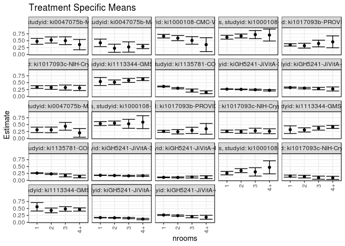

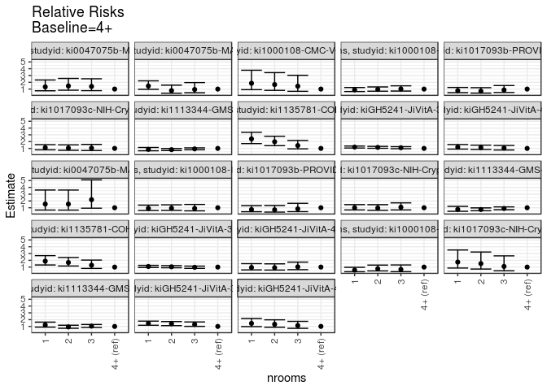

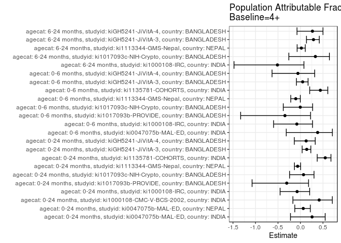

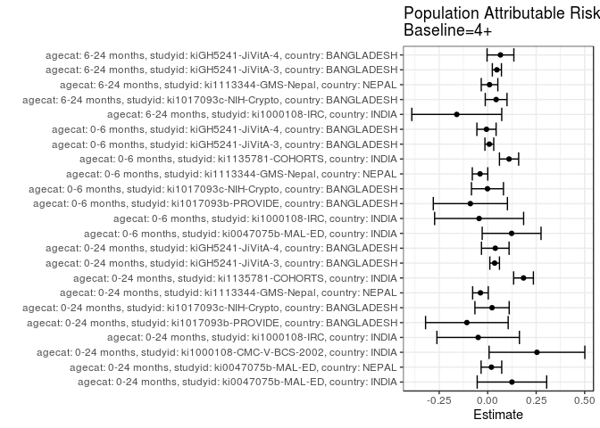

## Results Table

### Parameter: TSM

| agecat | studyid | country | intervention_level | baseline_level | estimate | ci_lower | ci_upper |
| --- | --- | --- | --- | --- | --- | --- | --- |
| 0-24 months | ki0047075b-MAL-ED | INDIA | 4+ | NA | 0.3600000 | 0.1714418 | 0.5485582 |
| 0-24 months | ki0047075b-MAL-ED | INDIA | 1 | NA | 0.4761905 | 0.3691590 | 0.5832219 |
| 0-24 months | ki0047075b-MAL-ED | INDIA | 2 | NA | 0.5256410 | 0.4145894 | 0.6366927 |
| 0-24 months | ki0047075b-MAL-ED | INDIA | 3 | NA | 0.5000000 | 0.3582499 | 0.6417501 |
| 0-24 months | ki0047075b-MAL-ED | NEPAL | 4+ | NA | 0.2900763 | 0.2122016 | 0.3679511 |
| 0-24 months | ki0047075b-MAL-ED | NEPAL | 1 | NA | 0.4230769 | 0.2885104 | 0.5576435 |
| 0-24 months | ki0047075b-MAL-ED | NEPAL | 2 | NA | 0.2258065 | 0.0783098 | 0.3733031 |
| 0-24 months | ki0047075b-MAL-ED | NEPAL | 3 | NA | 0.2727273 | 0.0862303 | 0.4592242 |
| 0-24 months | ki1000108-CMC-V-BCS-2002 | INDIA | 4+ | NA | 0.3571429 | 0.1058123 | 0.6084734 |
| 0-24 months | ki1000108-CMC-V-BCS-2002 | INDIA | 1 | NA | 0.6633663 | 0.5981118 | 0.7286209 |
| 0-24 months | ki1000108-CMC-V-BCS-2002 | INDIA | 2 | NA | 0.5943396 | 0.5007394 | 0.6879398 |
| 0-24 months | ki1000108-CMC-V-BCS-2002 | INDIA | 3 | NA | 0.5098039 | 0.3724211 | 0.6471867 |
| 0-24 months | ki1000108-IRC | INDIA | 4+ | NA | 0.7058824 | 0.4890205 | 0.9227442 |
| 0-24 months | ki1000108-IRC | INDIA | 1 | NA | 0.6270270 | 0.5572557 | 0.6967983 |
| 0-24 months | ki1000108-IRC | INDIA | 2 | NA | 0.6705882 | 0.5998500 | 0.7413264 |
| 0-24 months | ki1000108-IRC | INDIA | 3 | NA | 0.7222222 | 0.5757302 | 0.8687142 |
| 0-24 months | ki1017093b-PROVIDE | BANGLADESH | 4+ | NA | 0.4587278 | 0.2419793 | 0.6754763 |
| 0-24 months | ki1017093b-PROVIDE | BANGLADESH | 1 | NA | 0.3489809 | 0.3073849 | 0.3905769 |
| 0-24 months | ki1017093b-PROVIDE | BANGLADESH | 2 | NA | 0.3203275 | 0.2331120 | 0.4075431 |
| 0-24 months | ki1017093b-PROVIDE | BANGLADESH | 3 | NA | 0.3976719 | 0.2771959 | 0.5181479 |
| 0-24 months | ki1017093c-NIH-Crypto | BANGLADESH | 4+ | NA | 0.3073332 | 0.2132765 | 0.4013900 |
| 0-24 months | ki1017093c-NIH-Crypto | BANGLADESH | 1 | NA | 0.3405210 | 0.2920938 | 0.3889482 |
| 0-24 months | ki1017093c-NIH-Crypto | BANGLADESH | 2 | NA | 0.3233933 | 0.2565727 | 0.3902139 |
| 0-24 months | ki1017093c-NIH-Crypto | BANGLADESH | 3 | NA | 0.3217921 | 0.2299096 | 0.4136745 |
| 0-24 months | ki1113344-GMS-Nepal | NEPAL | 4+ | NA | 0.6275816 | 0.5738442 | 0.6813191 |
| 0-24 months | ki1113344-GMS-Nepal | NEPAL | 1 | NA | 0.5411874 | 0.3977237 | 0.6846512 |
| 0-24 months | ki1113344-GMS-Nepal | NEPAL | 2 | NA | 0.5145875 | 0.4319907 | 0.5971843 |
| 0-24 months | ki1113344-GMS-Nepal | NEPAL | 3 | NA | 0.5830241 | 0.5104117 | 0.6556365 |
| 0-24 months | ki1135781-COHORTS | INDIA | 4+ | NA | 0.1506643 | 0.0999743 | 0.2013543 |
| 0-24 months | ki1135781-COHORTS | INDIA | 1 | NA | 0.3622803 | 0.3462935 | 0.3782671 |

[output cut: 62 more lines]

### Parameter: E(Y)

| agecat | studyid | country | intervention_level | baseline_level | estimate | ci_lower | ci_upper |
| --- | --- | --- | --- | --- | --- | --- | --- |
| 0-24 months | ki0047075b-MAL-ED | INDIA | NA | NA | 0.4851064 | 0.4210714 | 0.5491414 |
| 0-24 months | ki0047075b-MAL-ED | NEPAL | NA | NA | 0.3093220 | 0.2502261 | 0.3684179 |
| 0-24 months | ki1000108-CMC-V-BCS-2002 | INDIA | NA | NA | 0.6112601 | 0.5617242 | 0.6607959 |
| 0-24 months | ki1000108-IRC | INDIA | NA | NA | 0.6568627 | 0.6107393 | 0.7029862 |
| 0-24 months | ki1017093b-PROVIDE | BANGLADESH | NA | NA | 0.3514286 | 0.3160364 | 0.3868207 |
| 0-24 months | ki1017093c-NIH-Crypto | BANGLADESH | NA | NA | 0.3298153 | 0.2963239 | 0.3633067 |
| 0-24 months | ki1113344-GMS-Nepal | NEPAL | NA | NA | 0.5903790 | 0.5535526 | 0.6272054 |
| 0-24 months | ki1135781-COHORTS | INDIA | NA | NA | 0.3354454 | 0.3228114 | 0.3480794 |
| 0-24 months | kiGH5241-JiVitA-3 | BANGLADESH | NA | NA | 0.2579663 | 0.2514934 | 0.2644392 |
| 0-24 months | kiGH5241-JiVitA-4 | BANGLADESH | NA | NA | 0.3101161 | 0.2957091 | 0.3245231 |
| 0-6 months | ki0047075b-MAL-ED | INDIA | NA | NA | 0.3234043 | 0.2634696 | 0.3833389 |
| 0-6 months | ki1000108-IRC | INDIA | NA | NA | 0.5441176 | 0.4957312 | 0.5925041 |
| 0-6 months | ki1017093b-PROVIDE | BANGLADESH | NA | NA | 0.2585714 | 0.2261125 | 0.2910304 |
| 0-6 months | ki1017093c-NIH-Crypto | BANGLADESH | NA | NA | 0.2572559 | 0.2261171 | 0.2883948 |
| 0-6 months | ki1113344-GMS-Nepal | NEPAL | NA | NA | 0.3760933 | 0.3398180 | 0.4123685 |
| 0-6 months | ki1135781-COHORTS | INDIA | NA | NA | 0.2494186 | 0.2376119 | 0.2612253 |
| 0-6 months | kiGH5241-JiVitA-3 | BANGLADESH | NA | NA | 0.1761899 | 0.1705583 | 0.1818216 |
| 0-6 months | kiGH5241-JiVitA-4 | BANGLADESH | NA | NA | 0.1078103 | 0.0979895 | 0.1176312 |
| 6-24 months | ki1000108-IRC | INDIA | NA | NA | 0.3112745 | 0.2662918 | 0.3562572 |
| 6-24 months | ki1017093c-NIH-Crypto | BANGLADESH | NA | NA | 0.1315069 | 0.1069744 | 0.1560393 |
| 6-24 months | ki1113344-GMS-Nepal | NEPAL | NA | NA | 0.4728814 | 0.4325613 | 0.5132014 |
| 6-24 months | kiGH5241-JiVitA-3 | BANGLADESH | NA | NA | 0.1637742 | 0.1576516 | 0.1698967 |
| 6-24 months | kiGH5241-JiVitA-4 | BANGLADESH | NA | NA | 0.2472801 | 0.2337480 | 0.2608122 |

### Parameter: RR

| agecat | studyid | country | intervention_level | baseline_level | estimate | ci_lower | ci_upper |
| --- | --- | --- | --- | --- | --- | --- | --- |
| 0-24 months | ki0047075b-MAL-ED | INDIA | 4+ | 4+ | 1.0000000 | 1.0000000 | 1.0000000 |
| 0-24 months | ki0047075b-MAL-ED | INDIA | 1 | 4+ | 1.3227513 | 0.7480773 | 2.3388906 |
| 0-24 months | ki0047075b-MAL-ED | INDIA | 2 | 4+ | 1.4601140 | 0.8300562 | 2.5684199 |
| 0-24 months | ki0047075b-MAL-ED | INDIA | 3 | 4+ | 1.3888889 | 0.7656184 | 2.5195482 |
| 0-24 months | ki0047075b-MAL-ED | NEPAL | 4+ | 4+ | 1.0000000 | 1.0000000 | 1.0000000 |
| 0-24 months | ki0047075b-MAL-ED | NEPAL | 1 | 4+ | 1.4585020 | 0.9619340 | 2.2114076 |
| 0-24 months | ki0047075b-MAL-ED | NEPAL | 2 | 4+ | 0.7784380 | 0.3841652 | 1.5773572 |
| 0-24 months | ki0047075b-MAL-ED | NEPAL | 3 | 4+ | 0.9401914 | 0.4509926 | 1.9600320 |
| 0-24 months | ki1000108-CMC-V-BCS-2002 | INDIA | 4+ | 4+ | 1.0000000 | 1.0000000 | 1.0000000 |
| 0-24 months | ki1000108-CMC-V-BCS-2002 | INDIA | 1 | 4+ | 1.8574257 | 0.9126746 | 3.7801318 |
| 0-24 months | ki1000108-CMC-V-BCS-2002 | INDIA | 2 | 4+ | 1.6641509 | 0.8091128 | 3.4227594 |
| 0-24 months | ki1000108-CMC-V-BCS-2002 | INDIA | 3 | 4+ | 1.4274510 | 0.6718852 | 3.0326854 |
| 0-24 months | ki1000108-IRC | INDIA | 4+ | 4+ | 1.0000000 | 1.0000000 | 1.0000000 |
| 0-24 months | ki1000108-IRC | INDIA | 1 | 4+ | 0.8882883 | 0.6406895 | 1.2315733 |
| 0-24 months | ki1000108-IRC | INDIA | 2 | 4+ | 0.9500000 | 0.6865201 | 1.3146009 |
| 0-24 months | ki1000108-IRC | INDIA | 3 | 4+ | 1.0231481 | 0.7080395 | 1.4784939 |
| 0-24 months | ki1017093b-PROVIDE | BANGLADESH | 4+ | 4+ | 1.0000000 | 1.0000000 | 1.0000000 |
| 0-24 months | ki1017093b-PROVIDE | BANGLADESH | 1 | 4+ | 0.7607581 | 0.4674412 | 1.2381299 |
| 0-24 months | ki1017093b-PROVIDE | BANGLADESH | 2 | 4+ | 0.6982955 | 0.4049757 | 1.2040638 |
| 0-24 months | ki1017093b-PROVIDE | BANGLADESH | 3 | 4+ | 0.8669017 | 0.4949149 | 1.5184806 |
| 0-24 months | ki1017093c-NIH-Crypto | BANGLADESH | 4+ | 4+ | 1.0000000 | 1.0000000 | 1.0000000 |
| 0-24 months | ki1017093c-NIH-Crypto | BANGLADESH | 1 | 4+ | 1.1079863 | 0.7904992 | 1.5529854 |
| 0-24 months | ki1017093c-NIH-Crypto | BANGLADESH | 2 | 4+ | 1.0522562 | 0.7273124 | 1.5223762 |
| 0-24 months | ki1017093c-NIH-Crypto | BANGLADESH | 3 | 4+ | 1.0470461 | 0.6889348 | 1.5913054 |
| 0-24 months | ki1113344-GMS-Nepal | NEPAL | 4+ | 4+ | 1.0000000 | 1.0000000 | 1.0000000 |
| 0-24 months | ki1113344-GMS-Nepal | NEPAL | 1 | 4+ | 0.8623379 | 0.6527081 | 1.1392944 |
| 0-24 months | ki1113344-GMS-Nepal | NEPAL | 2 | 4+ | 0.8199531 | 0.6834296 | 0.9837489 |
| 0-24 months | ki1113344-GMS-Nepal | NEPAL | 3 | 4+ | 0.9290012 | 0.7985623 | 1.0807463 |
| 0-24 months | ki1135781-COHORTS | INDIA | 4+ | 4+ | 1.0000000 | 1.0000000 | 1.0000000 |
| 0-24 months | ki1135781-COHORTS | INDIA | 1 | 4+ | 2.4045526 | 1.7125830 | 3.3761127 |

[output cut: 62 more lines]

### Parameter: PAR

| agecat | studyid | country | intervention_level | baseline_level | estimate | ci_lower | ci_upper |
| --- | --- | --- | --- | --- | --- | --- | --- |
| 0-24 months | ki0047075b-MAL-ED | INDIA | 4+ | NA | 0.1251064 | -0.0540303 | 0.3042430 |
| 0-24 months | ki0047075b-MAL-ED | NEPAL | 4+ | NA | 0.0192457 | -0.0338976 | 0.0723890 |
| 0-24 months | ki1000108-CMC-V-BCS-2002 | INDIA | 4+ | NA | 0.2541172 | 0.0073804 | 0.5008540 |
| 0-24 months | ki1000108-IRC | INDIA | 4+ | NA | -0.0490196 | -0.2617104 | 0.1636712 |
| 0-24 months | ki1017093b-PROVIDE | BANGLADESH | 4+ | NA | -0.1072992 | -0.3202244 | 0.1056260 |
| 0-24 months | ki1017093c-NIH-Crypto | BANGLADESH | 4+ | NA | 0.0224821 | -0.0658470 | 0.1108112 |
| 0-24 months | ki1113344-GMS-Nepal | NEPAL | 4+ | NA | -0.0372026 | -0.0775074 | 0.0031022 |
| 0-24 months | ki1135781-COHORTS | INDIA | 4+ | NA | 0.1847811 | 0.1338496 | 0.2357125 |
| 0-24 months | kiGH5241-JiVitA-3 | BANGLADESH | 4+ | NA | 0.0358783 | 0.0110358 | 0.0607207 |
| 0-24 months | kiGH5241-JiVitA-4 | BANGLADESH | 4+ | NA | 0.0391723 | -0.0319537 | 0.1102984 |
| 0-6 months | ki0047075b-MAL-ED | INDIA | 4+ | NA | 0.1234043 | -0.0283498 | 0.2751583 |
| 0-6 months | ki1000108-IRC | INDIA | 4+ | NA | -0.0441176 | -0.2735435 | 0.1853082 |
| 0-6 months | ki1017093b-PROVIDE | BANGLADESH | 4+ | NA | -0.0892547 | -0.2803091 | 0.1017998 |
| 0-6 months | ki1017093c-NIH-Crypto | BANGLADESH | 4+ | NA | -0.0010527 | -0.0834732 | 0.0813677 |
| 0-6 months | ki1113344-GMS-Nepal | NEPAL | 4+ | NA | -0.0393523 | -0.0792222 | 0.0005176 |
| 0-6 months | ki1135781-COHORTS | INDIA | 4+ | NA | 0.1101966 | 0.0607143 | 0.1596788 |
| 0-6 months | kiGH5241-JiVitA-3 | BANGLADESH | 4+ | NA | 0.0085326 | -0.0141847 | 0.0312498 |
| 0-6 months | kiGH5241-JiVitA-4 | BANGLADESH | 4+ | NA | -0.0061013 | -0.0556654 | 0.0434628 |
| 6-24 months | ki1000108-IRC | INDIA | 4+ | NA | -0.1593137 | -0.3911659 | 0.0725384 |
| 6-24 months | ki1017093c-NIH-Crypto | BANGLADESH | 4+ | NA | 0.0435947 | -0.0124970 | 0.0996865 |
| 6-24 months | ki1113344-GMS-Nepal | NEPAL | 4+ | NA | 0.0096003 | -0.0331248 | 0.0523254 |
| 6-24 months | kiGH5241-JiVitA-3 | BANGLADESH | 4+ | NA | 0.0474631 | 0.0239810 | 0.0709453 |
| 6-24 months | kiGH5241-JiVitA-4 | BANGLADESH | 4+ | NA | 0.0658889 | -0.0032340 | 0.1350118 |

### Parameter: PAF

| agecat | studyid | country | intervention_level | baseline_level | estimate | ci_lower | ci_upper |
| --- | --- | --- | --- | --- | --- | --- | --- |
| 0-24 months | ki0047075b-MAL-ED | INDIA | 4+ | NA | 0.2578947 | -0.2216217 | 0.5491892 |
| 0-24 months | ki0047075b-MAL-ED | NEPAL | 4+ | NA | 0.0622190 | -0.1262521 | 0.2191506 |
| 0-24 months | ki1000108-CMC-V-BCS-2002 | INDIA | 4+ | NA | 0.4157268 | -0.1682288 | 0.7077840 |
| 0-24 months | ki1000108-IRC | INDIA | 4+ | NA | -0.0746269 | -0.4526773 | 0.2050382 |
| 0-24 months | ki1017093b-PROVIDE | BANGLADESH | 4+ | NA | -0.3053230 | -1.0763324 | 0.1793856 |
| 0-24 months | ki1017093c-NIH-Crypto | BANGLADESH | 4+ | NA | 0.0681656 | -0.2421007 | 0.3009300 |
| 0-24 months | ki1113344-GMS-Nepal | NEPAL | 4+ | NA | -0.0630148 | -0.1337756 | 0.0033297 |
| 0-24 months | ki1135781-COHORTS | INDIA | 4+ | NA | 0.5508529 | 0.3723865 | 0.6785711 |
| 0-24 months | kiGH5241-JiVitA-3 | BANGLADESH | 4+ | NA | 0.1390812 | 0.0373435 | 0.2300668 |
| 0-24 months | kiGH5241-JiVitA-4 | BANGLADESH | 4+ | NA | 0.1263151 | -0.1367568 | 0.3285060 |
| 0-6 months | ki0047075b-MAL-ED | INDIA | 4+ | NA | 0.3815789 | -0.3160749 | 0.7094051 |
| 0-6 months | ki1000108-IRC | INDIA | 4+ | NA | -0.0810811 | -0.5969182 | 0.2681301 |
| 0-6 months | ki1017093b-PROVIDE | BANGLADESH | 4+ | NA | -0.3451838 | -1.3297335 | 0.2232934 |
| 0-6 months | ki1017093c-NIH-Crypto | BANGLADESH | 4+ | NA | -0.0040922 | -0.3814903 | 0.2702076 |
| 0-6 months | ki1113344-GMS-Nepal | NEPAL | 4+ | NA | -0.1046344 | -0.2160156 | -0.0034552 |
| 0-6 months | ki1135781-COHORTS | INDIA | 4+ | NA | 0.4418137 | 0.2058688 | 0.6076568 |
| 0-6 months | kiGH5241-JiVitA-3 | BANGLADESH | 4+ | NA | 0.0484283 | -0.0896440 | 0.1690049 |
| 0-6 months | kiGH5241-JiVitA-4 | BANGLADESH | 4+ | NA | -0.0565929 | -0.6317977 | 0.3158536 |
| 6-24 months | ki1000108-IRC | INDIA | 4+ | NA | -0.5118110 | -1.4765926 | 0.0771302 |
| 6-24 months | ki1017093c-NIH-Crypto | BANGLADESH | 4+ | NA | 0.3315017 | -0.2585388 | 0.6449137 |
| 6-24 months | ki1113344-GMS-Nepal | NEPAL | 4+ | NA | 0.0203016 | -0.0743558 | 0.1066192 |
| 6-24 months | kiGH5241-JiVitA-3 | BANGLADESH | 4+ | NA | 0.2898084 | 0.1324806 | 0.4186043 |
| 6-24 months | kiGH5241-JiVitA-4 | BANGLADESH | 4+ | NA | 0.2664546 | -0.0767061 | 0.5002454 |